# lab5

Collin Loy, Michelle Cryder

October 25, 2018

# Lab #5: Accident data

github: https://github.com/loycollin/lab5

## Outline

- Find your team members
- Create an R markdown file that contains all code to read the data and create the plots
- Submit!

# Find your team members

## FARS data

- US Department of transportation is keeping a record of every accident that results in a fatality in the FARS Data base (fatal accident report system, http://www.nhtsa.gov/FARS)
- FARS consists of 20+ tables consisting of various aspects of each accident Documentation at
- https://www-fars.nhtsa.dot.gov/Main/index.aspx
- three of the main tables are `accident`, `person`, and `vehicle`, stored in the data foler of our CANVAS page

## Data Background (2)

- Data of the three main tables is made available from our website.
- Load the accident data, plot latitude and longitude on a map.
- Variable names of the `accident.csv`:

```
##  [1] "STATE"      "ST_CASE"    "VE_TOTAL"   "VE_FORMS"   "PVH_INVL"
##  [6] "PEDS"       "PERNOTMVIT" "PERMVIT"    "PERSONS"    "COUNTY"
## [11] "CITY"       "DAY"        "MONTH"      "YEAR"       "DAY_WEEK"
## [16] "HOUR"       "MINUTE"     "NHS"        "RUR_URB"    "FUNC_SYS"
## [21] "RD_OWNER"   "ROUTE"      "TWAY_ID"    "TWAY_ID2"   "MILEPT"
## [26] "LATITUDE"   "LONGITUD"   "SP_JUR"     "HARM_EV"    "MAN_COLL"
## [31] "RELJCT1"    "RELJCT2"    "TYP_INT"    "WRK_ZONE"   "REL_ROAD"
## [36] "LGT_COND"   "WEATHER1"   "WEATHER2"   "WEATHER"    "SCH_BUS"
## [41] "RAIL"       "NOT_HOUR"   "NOT_MIN"    "ARR_HOUR"   "ARR_MIN"
## [46] "HOSP_HR"    "HOSP_MN"    "CF1"        "CF2"        "CF3"
## [51] "FATALS"     "DRUNK_DR"
```

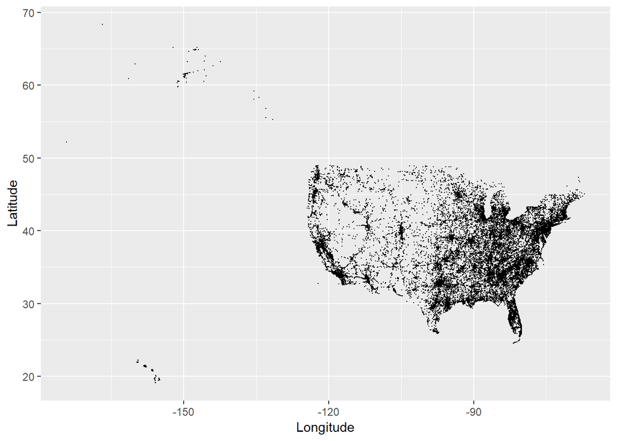

## Part one: Accident data

- are there some days of the week where more accidents happen than on others (use variable DAY_WEEK)?
  - The highest number of accidents occur on Saturday.
- what time of the day do accidents happen (use variable HOUR)?
  - 6:00 PM (Hour 18)
- what is the number of accidents with at least one drunk driver (use variable DRUNK_DR)?
  - The number of accidents wiht at least one drunk driver is 8720

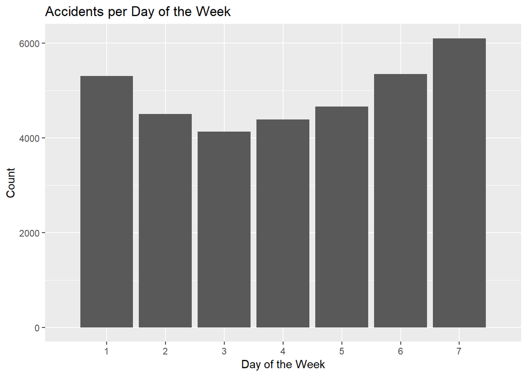

```r
acc %>% ggplot(aes(x = DAY_WEEK)) + geom_bar() + xlab("Day of the Week") + ylab("Count") + ggtitle("Accidents per Day of the Week") + scale_x_discrete(limits = c("1", "2", "3", "4", "5", "6", "7"))
```

```r
DWcount = count(acc, acc$DAY_WEEK)
DWcount
```

```
## # A tibble: 7 x 2
##   `acc$DAY_WEEK`     n
##            <int> <int>
## 1              1  5303
## 2              2  4501
## 3              3  4129
## 4              4  4388
## 5              5  4662
## 6              6  5352
## 7              7  6104
```

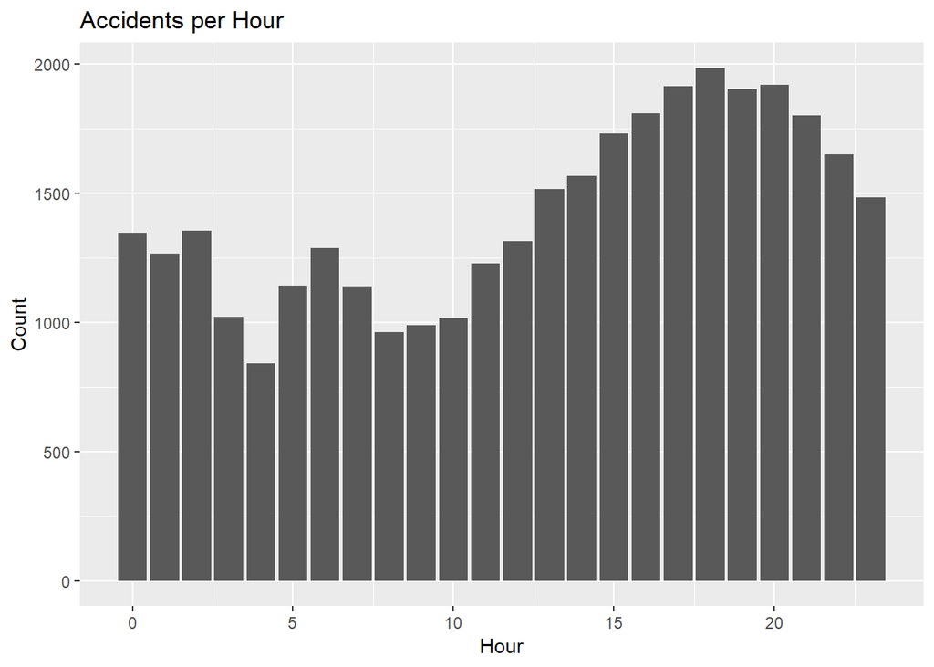

```r
acc %>% filter(HOUR <= 24) %>% ggplot(aes(x = HOUR)) + geom_bar() + xlab("Hour") + ylab("Count") + ggtitle("Accidents per Hour")
```

```r
Hcount = count(acc, acc$HOUR) %>% arrange(desc(n))
Hcount
```

```
## # A tibble: 25 x 2
##    `acc$HOUR`     n
##         <int> <int>
##  1         18  1984
##  2         20  1919
##  3         17  1913
##  4         19  1902
##  5         16  1808
##  6         21  1801
##  7         15  1731
##  8         22  1650
##  9         14  1567
## 10         13  1514
## # ... with 15 more rows
```

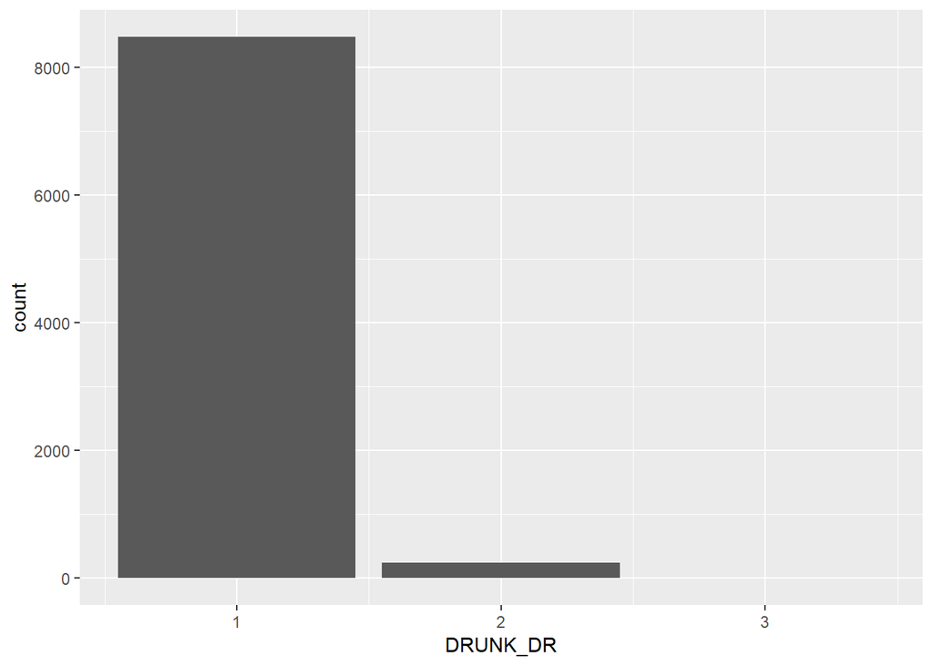

```r
acc %>% filter(DRUNK_DR >= 1) %>% ggplot(aes(x = DRUNK_DR)) + geom_bar()
```

```r
Dcount = acc %>% filter(DRUNK_DR >= 1) %>% count(DRUNK_DR)
Dcount
```

```
## # A tibble: 3 x 2
##   DRUNK_DR     n
##      <int> <int>
## 1        1  8474
## 2        2   243
## 3        3     3
```

```r
sum(Dcount$n)
```

```
## [1] 8720
```

## Part two: Connecting data

- Connect to the [person table](https://raw.githubusercontent.com/DS202-at-ISU/labs/master/data/fars2016/person.csv). Identify drivers (PER_TYP == 1, see fars manual ) and subset on them.
- Join accident and driver table (work out which variable(s) to use)
- Tally the number of accidents by day of the week (DAY_WEEK), hour of the day (HOUR) and gender (SEX). Visualize the results!

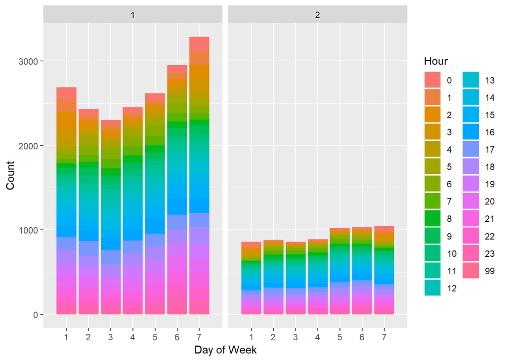

```r
person <- read.csv("https://raw.githubusercontent.com/DS202-at-ISU/labs/master/data/fars2016/person.csv")

person1 = person %>% filter(PER_TYP ==1)

accidentjoin2 = left_join(person1, acc, by = c("STATE", "ST_CASE"))


accidentjoin2 %>% filter(SEX == c(1,2)) %>% ggplot(aes(x = DAY_WEEK, fill = as.factor(HOUR.x))) + geom_bar() + facet_grid(~SEX) + scale_x_discrete(limits = c("1", "2", "3", "4", "5", "6", "7")) + xlab("Day of Week") + ylab("Count") + guides(fill=guide_legend("Hour"))
```

```r
accidentjoin2 %>% count(DAY_WEEK)
```

```
## # A tibble: 7 x 2
##   DAY_WEEK     n
##      <int> <int>
## 1        1  7475
## 2        2  6919
## 3        3  6304
## 4        4  6814
## 5        5  7244
## 6        6  8240
## 7        7  8918
```

```r
accidentjoin2 %>% count(HOUR.x)
```

```
## # A tibble: 25 x 2
##    HOUR.x     n
##     <int> <int>
##  1      0  1726
##  2      1  1634
##  3      2  1745
##  4      3  1334
##  5      4  1110
##  6      5  1644
##  7      6  1901
##  8      7  1816
##  9      8  1561
## 10      9  1669
## # ... with 15 more rows
```

```r
accidentjoin2 %>% count(SEX)
```

```
## # A tibble: 4 x 2
##     SEX     n
##   <int> <int>
## 1     1 37564
## 2     2 13279
## 3     8    76
## 4     9   995
```

```r
head(accidentjoin2)
```

```
##   STATE ST_CASE VE_FORMS.x VEH_NO PER_NO STR_VEH COUNTY.x DAY.x MONTH.x
## 1     1   10001          1      1      1       0       73     1       1
## 2     1   10002          1      1      1       0       73    10       1
## 3     1   10003          1      1      1       0       73     1       1
## 4     1   10004          1      1      1       0       73    17       1
## 5     1   10005          1      1      1       0       73    26       1
## 6     1   10006          1      1      1       0      109     1       1
##   HOUR.x MINUTE.x RUR_URB.x FUNC_SYS.x HARM_EV.x MAN_COLL.x SCH_BUS.x MAKE
## 1      9       25         2          1        42          0         0   20
## 2     19       59         2          1         1          0         0   37
## 3      2       20         1          1        14          0         0   20
## 4     21       45         1          1        25          0         0   20
## 5     20        7         2          1        42          0         0   20
## 6      1       10         1          4        42          0         0   49
##   MAK_MOD BODY_TYP MOD_YEAR TOW_VEH SPEC_USE EMER_USE ROLLOVER IMPACT1
```

[output cut: 83 more lines]

## Submission

In Canvas, submit an RMarkdown file (and the knitted html document) with:

1. the names of all team members that worked on the document.
2. a link to the github repo you were working in.
3. code and answers to all of the questions.
4. you can upload the data file, but you don’t have to

Due date: You have time until Monday at 10 pm to submit the final RMmarkdown file.